# Analysis: comparison of base R and ggplot

# Loading packages and reading data

```r
library(tidyverse)
library(xtable)
library(devtools)
summ_all <- read_csv("data/summ_all_FINAL.csv", guess_max = 1e6)
summ_comply <- read_csv("data/summ_comply_FINAL.csv", guess_max = 1e6)
sumtable1 <- read_csv("data/base_table_all_FINAL.csv", guess_max = 1e6)
```

```r
sumtable2 <- read_csv("data/ggplot_table_all_FINAL.csv", guess_max = 1e6)
sumtable1_no_upload_rm <- read_csv("data/base_table_FINAL.csv", guess_max = 1e6)
sumtable2_no_upload_rm <- read_csv("data/ggplot_table_FINAL.csv", guess_max = 1e6)
base_annots <- read_csv("data/base_annots_FINAL.csv", guess_max = 1e6)
ggplot_annots <- read_csv("data/ggplot_annots_FINAL.csv", guess_max = 1e6)
base_annots$peer_submission_is_draft[is.na(base_annots$peer_submission_is_draft)] <- FALSE
ggplot_annots$peer_submission_is_draft[is.na(ggplot_annots$peer_submission_is_draft)] <- FALSE
```

# Analysis

Create shorter versions of the prompts.

```r
prompts <- tibble(
    prompt = unique(summ_all$prompt),
    short_prompt = c(
        "Legends and labels sufficient?",
        "Text and labels large enough?",
        "Understandable without caption?",
        "Did they upload a plot?",
        "Use full words vs. abbreviations?",
        "Clearly shows relationships?",
        "Is the plot visually pleasing?",
        "Clearly shows relationship?"
    )
)
```

Add an indicator to the annotation data frames for whether the observation should be kept (submission was reviewed or not a draft submission if not reviewed).

```r
base_annots <- base_annots %>%
    mutate(
        reviewed = deid_url %in% sumtable1$deid_url,
        keep = reviewed | (!reviewed & !peer_submission_is_draft)
    ) %>%
    select(-reviewed) %>%
    filter(keep)
ggplot_annots <- ggplot_annots %>%
    mutate(
        reviewed = deid_url %in% sumtable2$deid_url,
        keep = reviewed | (!reviewed & !peer_submission_is_draft)
    ) %>%
    select(-reviewed) %>%
    filter(keep)
```

## Sample sizes

How many students participated in the trial?

Count the number of unique JHU user IDs.

```r
sum(is.na(sumtable1$deid_jhu_user_id))
```

```
## [1] 0
```

```r
sum(is.na(sumtable2$deid_jhu_user_id))
```

```
## [1] 0
```

```r
sum(is.na(base_annots %>% pull(deid_jhu_user_id)))
```

```
## [1] 20
```

```r
sum(is.na(ggplot_annots %>% pull(deid_jhu_user_id)))
```

```
## [1] 22
```

```r
## Base R
setdiff(sumtable1$deid_jhu_user_id, NA) %>% length()
```

[output not shown]

```r
setdiff(base_annots$deid_jhu_user_id, NA) %>% length()
```

```
## [1] 369
```

```r
setdiff(c(sumtable1$deid_jhu_user_id, base_annots$deid_jhu_user_id), NA) %>% length()
```

```
## [1] 412
```

```r
## ggplot
setdiff(sumtable2$deid_jhu_user_id, NA) %>% length()
```

```
## [1] 531
```

```r
setdiff(ggplot_annots$deid_jhu_user_id, NA) %>% length()
```

```
## [1] 531
```

```r
setdiff(c(sumtable2$deid_jhu_user_id, ggplot_annots$deid_jhu_user_id), NA) %>% length()
```

```
## [1] 567
```

How many plots were submitted?

```r
sum(is.na(base_annots$deid_url))
```

```
## [1] 0
```

```r
sum(is.na(ggplot_annots$deid_url))
```

```
## [1] 0
```

```r
urls_base_simple <- base_annots %>%
    filter(section=="simple") %>%
    pull(deid_url) %>%
    unique()
urls_base_complex <- base_annots %>%
    filter(section=="complex") %>%
    pull(deid_url) %>%
    unique()
length(urls_base_simple)
```

```
## [1] 385
```

```r
length(urls_base_complex)
```

```
## [1] 400
```

```r
length(urls_base_simple)+length(urls_base_complex)
```

```
## [1] 785
```

```r
urls_ggplot_simple <- ggplot_annots %>%
    filter(section=="simple") %>%
    pull(deid_url) %>%
    unique()
urls_ggplot_complex <- ggplot_annots %>%
    filter(section=="complex") %>%
    pull(deid_url) %>%
    unique()
length(urls_ggplot_simple)
```

```
## [1] 565
```

```r
length(urls_ggplot_complex)
```

```
## [1] 587
```

```r
length(urls_ggplot_simple)+length(urls_ggplot_complex)
```

```
## [1] 1152
```

How many of the submitted plots were reviewed? Answer: not all submitted plots underwent peer review.

```r
table(urls_base_simple %in% sumtable1_no_upload_rm$deid_url, useNA = "ifany")
```

```
##
## FALSE  TRUE
##    22   363
```

```r
table(urls_base_complex %in% sumtable1_no_upload_rm$deid_url, useNA = "ifany")
```

```
##
## FALSE  TRUE
##    34   366
```

```r
table(urls_ggplot_simple %in% sumtable2_no_upload_rm$deid_url, useNA = "ifany")
```

```
##
## FALSE  TRUE
##    44   521
```

```r
table(urls_ggplot_complex %in% sumtable2_no_upload_rm$deid_url, useNA = "ifany")
```

```
##
## FALSE  TRUE
##    64   523
```

How many peer reviews are there?

```r
num_reviews_base_simple <- (sumtable1 %>% filter(section=="simple") %>% nrow())/7
num_reviews_base_complex <- (sumtable1 %>% filter(section=="complex") %>% nrow())/7
num_reviews_base_simple
```

```
## [1] 1267
```

```r
num_reviews_base_complex
```

```
## [1] 1267
```

```r
num_reviews_ggplot_simple <- (sumtable2 %>% filter(section=="simple") %>% nrow())/7
num_reviews_ggplot_complex <- (sumtable2 %>% filter(section=="complex") %>% nrow())/7
num_reviews_ggplot_simple
```

```
## [1] 1440
```

```r
num_reviews_ggplot_complex
```

```
## [1] 1440
```

How many peer reviews were removed when removing reviews where upload=“No”? How many plots does that correspond to?

```r
num_reviews_base_simple_subs <- (sumtable1_no_upload_rm %>% filter(section=="simple") %>% nrow())/7
num_reviews_base_complex_subs <- (sumtable1_no_upload_rm %>% filter(section=="complex") %>% nrow())/7
num_reviews_base_simple - num_reviews_base_simple_subs
```

```
## [1] 21
```

```r
num_reviews_base_complex - num_reviews_base_complex_subs
```

```
## [1] 22
```

```r
num_reviews_base_simple_subs
```

```
## [1] 1246
```

```r
num_reviews_base_complex_subs
```

```
## [1] 1245
```

```r
num_reviews_ggplot_simple_subs <- (sumtable2_no_upload_rm %>% filter(section=="simple") %>% nrow())/7
num_reviews_ggplot_complex_subs <- (sumtable2_no_upload_rm %>% filter(section=="complex") %>% nrow())/7
num_reviews_ggplot_simple - num_reviews_ggplot_simple_subs
```

```
## [1] 12
```

```r
num_reviews_ggplot_complex - num_reviews_ggplot_complex_subs
```

```
## [1] 15
```

```r
num_reviews_ggplot_simple_subs
```

```
## [1] 1428
```

```r
num_reviews_ggplot_complex_subs
```

```
## [1] 1425
```

What is the distribution of the number of submissions reviewed by a single student?

```
## # unique IDs per review:
## .
##    1
## 1256
## Total # unique IDs:
## [1] 382
## Range, mean, median of # submissions reviewed by a reviewer :
## [1]  1 34
## [1] 3.287958
## [1] 3
```

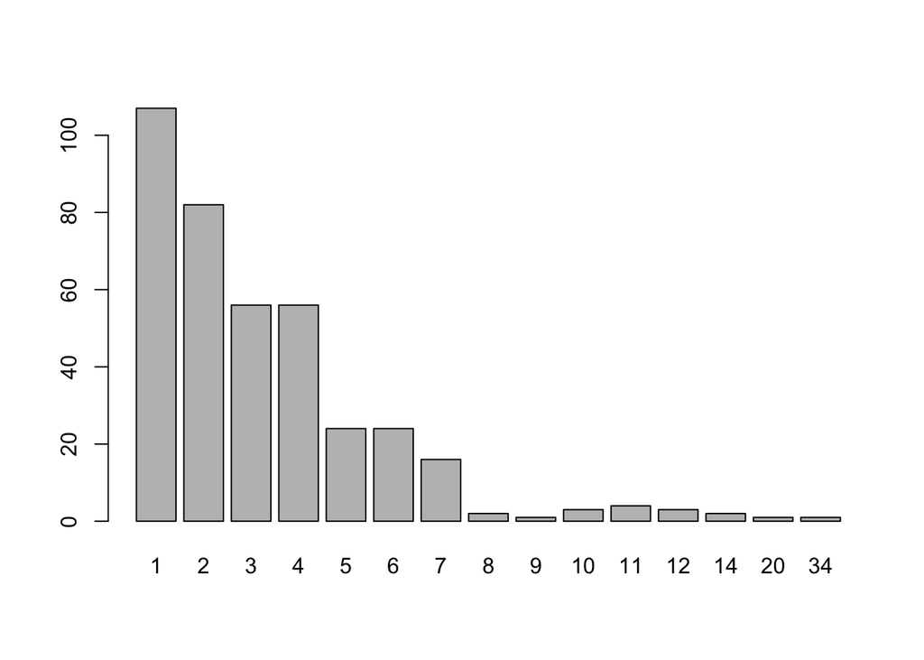

```r
distribution_num_reviewed <- function(sumtable, what = c("deid_jhu_user_id", "deid_url")) {
    what <- match.arg(what)
    review_ids <- unique(sumtable$deid_peer_review_id)
    user_ids <- lapply(review_ids, function(id) {
        df_subs <- sumtable %>%
            filter(deid_peer_review_id==id)
        unique(df_subs[[what]])
    })
    cat("# unique IDs per review:\n")
    print(lengths(user_ids) %>% table())
    user_ids <- unlist(user_ids)
    cat("Total # unique IDs:\n")
    print(user_ids %>% unique() %>% length())
    num_reviewed <- table(user_ids)
    if (what=="deid_jhu_user_id") {
        thing <- "# submissions reviewed by a reviewer"
    } else if (what=="deid_url") {
        thing <- "# reviewers who reviewed a plot"
    }
    cat("Range, mean, median of", thing, ":\n")
    print(range(num_reviewed))
    print(mean(num_reviewed))
    print(median(num_reviewed))
    barplot(user_ids %>% table() %>% table())
}
distribution_num_reviewed(sumtable1_no_upload_rm, what = "deid_jhu_user_id")
```

```r
distribution_num_reviewed(sumtable2_no_upload_rm, what = "deid_jhu_user_id")
```

```
## # unique IDs per review:
## .
##    1
## 1429
## Total # unique IDs:
## [1] 531
## Range, mean, median of # submissions reviewed by a reviewer :
## [1]  1 25
## [1] 2.691149
## [1] 2
```

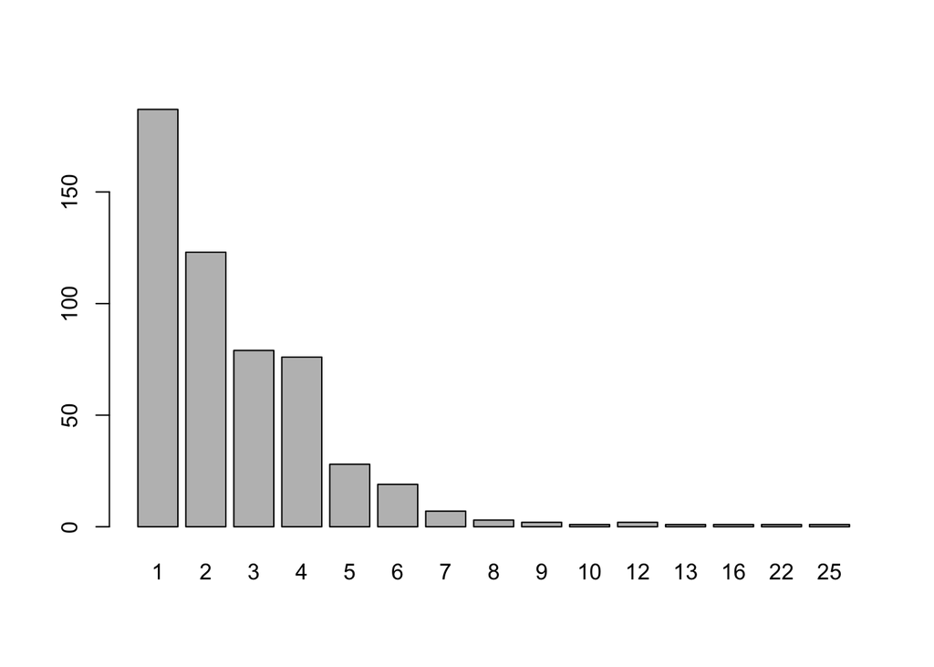

```r
distribution_num_reviewed(sumtable1, what = "deid_jhu_user_id")
```

```
## # unique IDs per review:
## .
##    0    1
##    1 1256
## Total # unique IDs:
## [1] 382
## Range, mean, median of # submissions reviewed by a reviewer :
## [1]  1 34
## [1] 3.287958
## [1] 3
```

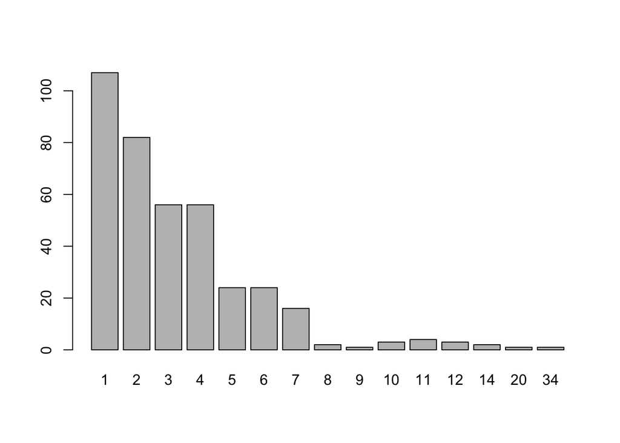

```r
distribution_num_reviewed(sumtable2, what = "deid_jhu_user_id")
```

```
## # unique IDs per review:
## .
##    0    1
##    1 1429
## Total # unique IDs:
## [1] 531
## Range, mean, median of # submissions reviewed by a reviewer :
## [1]  1 25
## [1] 2.691149
## [1] 2
```

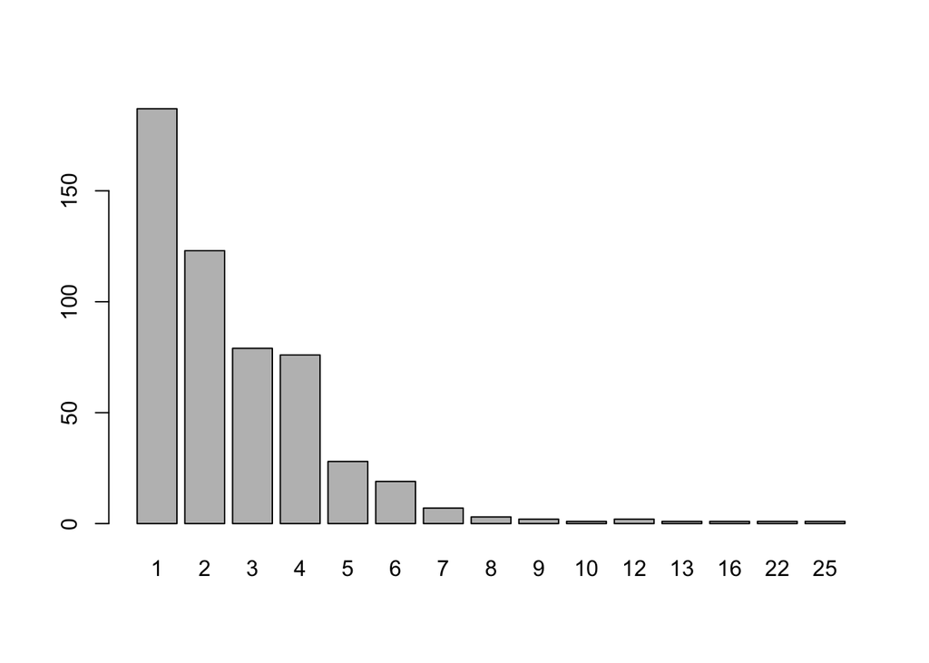

Each plot was reviewed by how many students?

```r
distribution_num_reviewed(sumtable1_no_upload_rm, what = "deid_url")
```

```
## # unique IDs per review:
## .
##    1    2
##   22 1234
## Total # unique IDs:
## [1] 730
## Range, mean, median of # reviewers who reviewed a plot :
## [1]  1 12
## [1] 3.38546
## [1] 3
```

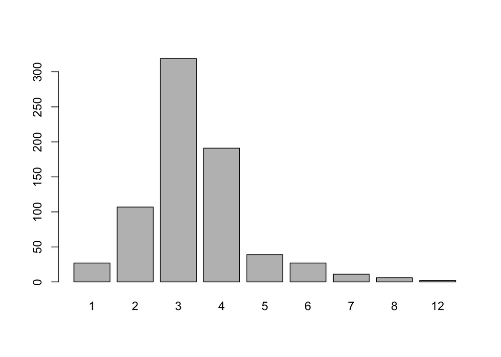

```r
distribution_num_reviewed(sumtable2_no_upload_rm, what = "deid_url")
```

```
## # unique IDs per review:
## .
##    1    2
##    5 1424
## Total # unique IDs:
## [1] 1045
## Range, mean, median of # reviewers who reviewed a plot :
## [1]  1 28
## [1] 2.722222
## [1] 2
```

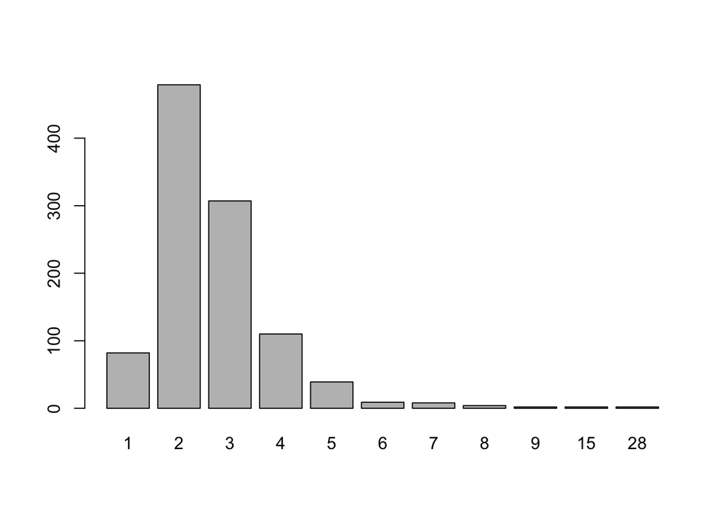

```r
distribution_num_reviewed(sumtable1, what = "deid_url")
```

```
## # unique IDs per review:
## .
##    0    1    2
##    1    1 1255
## Total # unique IDs:
## [1] 732
## Range, mean, median of # reviewers who reviewed a plot :
## [1]  1 12
## [1] 3.393981
## [1] 3
```

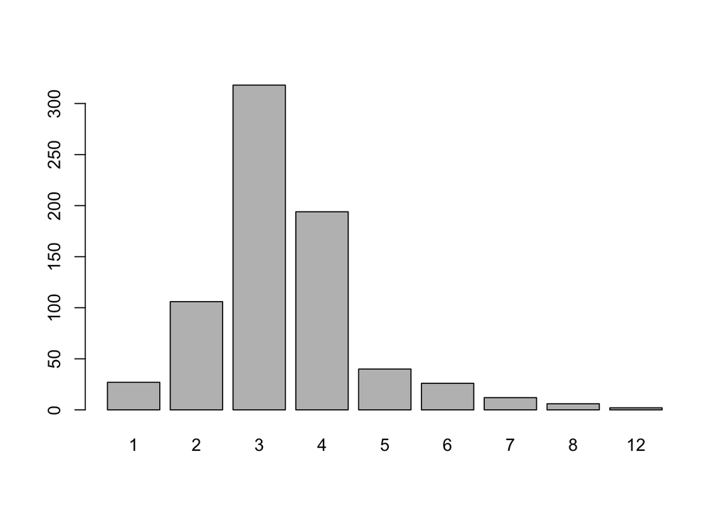

```r
distribution_num_reviewed(sumtable2, what = "deid_url")
```

```
## # unique IDs per review:
## .
##    0    2
##    1 1429
## Total # unique IDs:
## [1] 1046
## Range, mean, median of # reviewers who reviewed a plot :
## [1]  1 28
## [1] 2.724402
## [1] 2
```

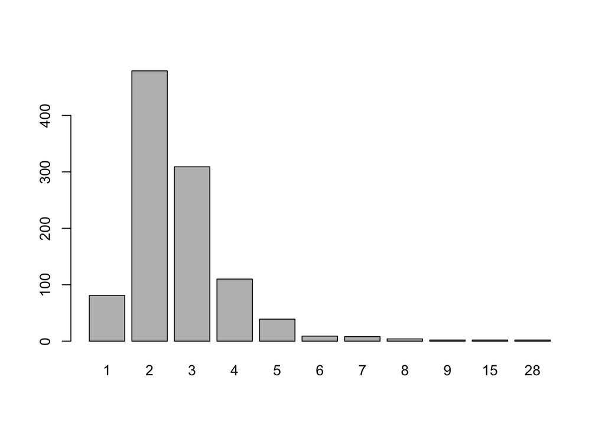

## Compliance status

For how many URLs is correct_system TRUE? In other words, what fraction of submissions were made in the correct plotting system?

```r
count_compliance <- function(annots, plot_type = c("simple", "complex")) {
    plot_type <- match.arg(plot_type)
    annots %>%
        filter(keep, section==plot_type) %>%
        select(deid_url, correct_system) %>%
        unique() %>%
        count(correct_system)
}
comply_base_simple <- count_compliance(base_annots, plot_type = "simple")
comply_base_complex <- count_compliance(base_annots, plot_type = "complex")

comply_ggplot_simple <- count_compliance(ggplot_annots, plot_type = "simple")
comply_ggplot_complex <- count_compliance(ggplot_annots, plot_type = "complex")

df_comply <- data.frame(
    arm = rep(c("Base R", "ggplot2"), each = 2),
    plot = rep(c("simple", "complex"), 2),
    num_plots = c(
        sum(comply_base_simple$n),
        sum(comply_base_complex$n),
        sum(comply_ggplot_simple$n),
        sum(comply_ggplot_complex$n)
    ),
    num_annot = c(
        sum(comply_base_simple$n[!is.na(comply_base_simple$correct_system)]),
        sum(comply_base_complex$n[!is.na(comply_base_complex$correct_system)]),
        sum(comply_ggplot_simple$n[!is.na(comply_ggplot_simple$correct_system)]),
        sum(comply_ggplot_complex$n[!is.na(comply_ggplot_complex$correct_system)])
    )
)
num_compliant <- c(
    comply_base_simple %>% filter(correct_system) %>% pull(n),
    comply_base_complex %>% filter(correct_system) %>% pull(n),
    comply_ggplot_simple %>% filter(correct_system) %>% pull(n),
    comply_ggplot_complex %>% filter(correct_system) %>% pull(n)
)
perc_compliant <- paste0(round(num_compliant/df_comply$num_annot, 3)*100, "%")
df_comply$perc_compliant <- paste0(perc_compliant, " (", num_compliant, "/", df_comply$num_annot, ")")
colnames(df_comply) <- c("Arm", "Plot", "# plots", "# annotated", "% compliant")
print(xtable(df_comply), include.rownames = FALSE)
```

```
## % latex table generated in R 3.5.2 by xtable 1.8-4 package
## % Sat Aug 31 23:27:45 2019
## \begin{table}[ht]
## \centering
## \begin{tabular}{llrrl}
##   \hline
## Arm & Plot & \# plots & \# annotated & \% compliant \\
##   \hline
## Base R & simple & 385 & 385 & 92.7\% (357/385) \\
##   Base R & complex & 400 & 399 & 87.5\% (349/399) \\
##   ggplot2 & simple & 565 & 561 & 99.5\% (558/561) \\
##   ggplot2 & complex & 587 & 584 & 99.7\% (582/584) \\
##    \hline
## \end{tabular}
## \end{table}
```

```r
## 95% CIs for comparing compliance between arms
## Simple
prop.test(x = c(558, 357), n = c(561, 385))
```

```
##
##  2-sample test for equality of proportions with continuity
##  correction
##
## data:  c(558, 357) out of c(561, 385)
## X-squared = 30.612, df = 1, p-value = 3.152e-08
## alternative hypothesis: two.sided
## 95 percent confidence interval:
##  0.03855691 0.09620245
## sample estimates:
##    prop 1    prop 2
## 0.9946524 0.9272727
```

```r
0.9946524-0.9272727
```

```
## [1] 0.0673797
```

```r
## Complex
prop.test(x = c(582, 349), n = c(584, 399))
```

```
##
##  2-sample test for equality of proportions with continuity
##  correction
##
## data:  c(582, 349) out of c(584, 399)
## X-squared = 67.881, df = 1, p-value < 2.2e-16
## alternative hypothesis: two.sided
## 95 percent confidence interval:
##  0.08695034 0.15682691
## sample estimates:
##    prop 1    prop 2
## 0.9965753 0.8746867
```

```r
0.9965753-0.8746867
```

```
## [1] 0.1218886
```

Go to each review and tabulate compliance for the simple plot and the complex plot.

```r
base_comply_sections <- sumtable1_no_upload_rm %>%
    group_by(deid_peer_review_id, section) %>%
    summarize(
        urls = paste(unique(deid_url), collapse = ","),
        comply = paste(unique(correct_system), collapse = ",")
    )
base_comply_sections$comply[base_comply_sections$comply=="NA"] <- NA
ggplot_comply_sections <- sumtable2_no_upload_rm %>%
    group_by(deid_peer_review_id, section) %>%
    summarize(
        urls = paste(unique(deid_url), collapse = ","),
        comply = paste(unique(correct_system), collapse = ",")
    )
ggplot_comply_sections$comply[ggplot_comply_sections$comply=="NA"] <- NA
base_comply_sections2 <- do.call(rbind, lapply(base_comply_sections$deid_peer_review_id, function(id) {
    df_subs <- base_comply_sections %>% filter(deid_peer_review_id==id)
    if (sum(df_subs$section=="simple")==0) {
        url_simple <- NA
        comply_simple <- NA
    } else {
        url_simple <- df_subs$urls[df_subs$section=="simple"]
        comply_simple <- df_subs$comply[df_subs$section=="simple"]
    }
    if (sum(df_subs$section=="complex")==0) {
        url_complex <- NA
        comply_complex <- NA
    } else {
        url_complex <- df_subs$urls[df_subs$section=="complex"]
        comply_complex <- df_subs$comply[df_subs$section=="complex"]
    }
    data.frame(
        url_simple = url_simple,
        url_complex = url_complex,
        comply_simple = comply_simple,
        comply_complex = comply_complex,
        stringsAsFactors = FALSE
    )
}))
ggplot_comply_sections2 <- do.call(rbind, lapply(ggplot_comply_sections$deid_peer_review_id, function(id) {
    df_subs <- ggplot_comply_sections %>% filter(deid_peer_review_id==id)
    if (sum(df_subs$section=="simple")==0) {
        url_simple <- NA
        comply_simple <- NA
    } else {
        url_simple <- df_subs$urls[df_subs$section=="simple"]
        comply_simple <- df_subs$comply[df_subs$section=="simple"]
    }
    if (sum(df_subs$section=="complex")==0) {
        url_complex <- NA
        comply_complex <- NA
    } else {
        url_complex <- df_subs$urls[df_subs$section=="complex"]
        comply_complex <- df_subs$comply[df_subs$section=="complex"]
    }
    data.frame(
        url_simple = url_simple,
        url_complex = url_complex,
        comply_simple = comply_simple,
        comply_complex = comply_complex,
        stringsAsFactors = FALSE
    )
}))
base_comply_sections2 <- unique(base_comply_sections2)
ggplot_comply_sections2 <- unique(ggplot_comply_sections2)

base_comply_sections_summ <- base_comply_sections2 %>%
    count(comply_simple, comply_complex) %>%
    arrange(desc(n))
ggplot_comply_sections_summ <- ggplot_comply_sections2 %>%
    count(comply_simple, comply_complex) %>%
    arrange(desc(n))

base_comply_sections_summ
```

```
## # A tibble: 8 x 3
##   comply_simple comply_complex     n
##   <chr>         <chr>          <int>
## 1 TRUE          TRUE             319
## 2 FALSE         FALSE             25
## 3 TRUE          FALSE             17
## 4 TRUE          <NA>               8
## 5 <NA>          TRUE               6
## 6 FALSE         <NA>               2
## 7 <NA>          FALSE              2
## 8 <NA>          <NA>               1
```

```r
ggplot_comply_sections_summ
```

```
## # A tibble: 7 x 3
##   comply_simple comply_complex     n
##   <chr>         <chr>          <int>
## 1 TRUE          TRUE             515
## 2 TRUE          <NA>               7
## 3 <NA>          TRUE               3
## 4 FALSE         TRUE               2
## 5 FALSE         FALSE              1
## 6 TRUE          FALSE              1
## 7 <NA>          <NA>               1
```

```r
319+25+17
```

```
## [1] 361
```

```r
515+2+1+1
```

```
## [1] 519
```

## Overall summary tables

Make a table that has a row for every rubric question+response possible (excluding no’s) and proportions for base R, ggplot2, and difference in proportions. CIs should be displayed too.

```r
make_results_table <- function(sum_tab) {
    prompts_ordered <- c(
        "Clearly shows",
        "visually pleasing",
        "caption",
        "Legends and labels",
        "Text and labels",
        "abbreviations"
            )
    do.call(rbind, lapply(c("simple", "complex"), function(sect) {
        do.call(rbind, lapply(prompts_ordered, function(p) {
            sub_tbl <- sum_tab %>%
                filter(short_prompt %>% str_detect(p)) %>%
                filter(section==sect)
            responses <- unique(sub_tbl$option)
            do.call(rbind, lapply(responses, function(resp) {
                sub_tbl2 <- sub_tbl %>% filter(option==resp)
                count_base <- sub_tbl2 %>% filter(arm=="base") %>% pull(count)
                tot_base <- sub_tbl2 %>% filter(arm=="base") %>% pull(total_reviews)
                count_gg <- sub_tbl2 %>% filter(arm=="ggplot") %>% pull(count)
                tot_gg <- sub_tbl2 %>% filter(arm=="ggplot") %>% pull(total_reviews)
                ptest_res <- prop.test(x = c(count_base, count_gg), n = c(tot_base, tot_gg))
                # is_signif <- length(unique(sign(ptest_res$conf.int)))==1
                stopifnot(length(unique(sub_tbl2$short_prompt))==1)
                prop_diff <- diff(ptest_res$estimate) %>% round(3)
                prop_diff <- paste0(prop_diff*100, "%")
                ci_prop_diff <- -rev(ptest_res$conf.int) %>% round(3)
                ci_prop_diff <- paste0("(", paste0(ci_prop_diff*100, "%", collapse = ", "), ")")
                # if (is_signif) {
                #     ci_prop_diff <- paste0(ci_prop_diff, "*")
                # }
                data.frame(
                    "Plot" = sect,
                    "Prompt" = sub_tbl2$short_prompt[1],
                    "Response" = resp,
                    "Base R" = paste0(round(ptest_res$estimate[1], 3)*100, "% (", count_base, "/", tot_base, ")"),
                    "ggplot2" = paste0(round(ptest_res$estimate[2], 3)*100, "% (", count_gg, "/", tot_gg, ")"),
                    "ggplot2 - base R" = paste(prop_diff, ci_prop_diff)
                )
            }))
        }))
    }))
}

summ_all_clean <- summ_all %>%
    filter(option != "No") %>%
    left_join(prompts)
results_table <- make_results_table(summ_all_clean)
rownames(results_table) <- NULL
colnames(results_table) <- c("Plot", "Prompt", "Response", "Base R", "ggplot2", "ggplot2 - base R")
print(xtable(results_table), include.rownames = FALSE)
```

```
## % latex table generated in R 3.5.2 by xtable 1.8-4 package
## % Sat Aug 31 23:28:08 2019
## \begin{table}[ht]
## \centering
## \begin{tabular}{llllll}
##   \hline
## Plot & Prompt & Response & Base R & ggplot2 & ggplot2 - base R \\
##   \hline
## simple & Clearly shows relationship? & Yes & 86.2\% (1074/1246) & 89.7\% (1281/1428) & 3.5\% (1\%, 6.1\%) \\
##   simple & Is the plot visually pleasing? & Somewhat & 23.1\% (288/1246) & 18.3\% (261/1428) & -4.8\% (-8\%, -1.7\%) \\
##   simple & Is the plot visually pleasing? & Yes & 73.7\% (918/1246) & 80.5\% (1150/1428) & 6.9\% (3.6\%, 10.1\%) \\
##   simple & Understandable without caption? & Yes & 90.9\% (1132/1246) & 91\% (1299/1428) & 0.1\% (-2.1\%, 2.4\%) \\
##   simple & Legends and labels sufficient? & Yes & 89.4\% (1114/1246) & 90.8\% (1296/1428) & 1.4\% (-1\%, 3.7\%) \\
##   simple & Text and labels large enough? & Yes & 97.8\% (1219/1246) & 99\% (1414/1428) & 1.2\% (0.2\%, 2.2\%) \\
##   simple & Use full words vs. abbreviations? & Yes & 95.4\% (1189/1246) & 96.1\% (1373/1428) & 0.7\% (-0.9\%, 2.3\%) \\
##   complex & Clearly shows relationships? & Yes & 72.3\% (900/1245) & 83.6\% (1192/1425) & 11.4\% (8.1\%, 14.6\%) \\
##   complex & Is the plot visually pleasing? & Somewhat & 30\% (374/1245) & 30.8\% (439/1425) & 0.8\% (-2.8\%, 4.3\%) \\
##   complex & Is the plot visually pleasing? & Yes & 59.5\% (741/1245) & 60.6\% (863/1425) & 1\% (-2.8\%, 4.8\%) \\
##   complex & Understandable without caption? & Yes & 76.8\% (956/1245) & 81.5\% (1161/1425) & 4.7\% (1.5\%, 7.9\%) \\
##   complex & Legends and labels sufficient? & Yes & 77.9\% (970/1245) & 82.4\% (1174/1425) & 4.5\% (1.4\%, 7.6\%) \\
##   complex & Text and labels large enough? & Yes & 89.8\% (1118/1245) & 86.3\% (1230/1425) & -3.5\% (-6\%, -1\%) \\
##   complex & Use full words vs. abbreviations? & Yes & 83.6\% (1041/1245) & 85.4\% (1217/1425) & 1.8\% (-1\%, 4.6\%) \\
##    \hline
## \end{tabular}
## \end{table}
```

```r
summ_comply_clean <- summ_comply %>%
    filter(option != "No") %>%
    left_join(prompts)
```

```r
results_table_comply <- make_results_table(summ_comply_clean)
rownames(results_table_comply) <- NULL
colnames(results_table_comply) <- c("Plot", "Prompt", "Response", "Base R", "ggplot2", "ggplot2 - base R")
print(xtable(results_table_comply), include.rownames = FALSE)
```

```
## % latex table generated in R 3.5.2 by xtable 1.8-4 package
## % Sat Aug 31 23:28:08 2019
## \begin{table}[ht]
## \centering
## \begin{tabular}{llllll}
##   \hline
## Plot & Prompt & Response & Base R & ggplot2 & ggplot2 - base R \\
##   \hline
## simple & Clearly shows relationship? & Yes & 85.8\% (1005/1172) & 89.7\% (1278/1424) & 4\% (1.4\%, 6.6\%) \\
##   simple & Is the plot visually pleasing? & Somewhat & 23.4\% (274/1172) & 18.2\% (259/1424) & -5.2\% (-8.4\%, -2\%) \\
##   simple & Is the plot visually pleasing? & Yes & 73.3\% (859/1172) & 80.6\% (1148/1424) & 7.3\% (4\%, 10.7\%) \\
##   simple & Understandable without caption? & Yes & 90.8\% (1064/1172) & 90.9\% (1295/1424) & 0.2\% (-2.1\%, 2.5\%) \\
##   simple & Legends and labels sufficient? & Yes & 89.5\% (1049/1172) & 90.7\% (1292/1424) & 1.2\% (-1.2\%, 3.6\%) \\
##   simple & Text and labels large enough? & Yes & 97.9\% (1147/1172) & 99\% (1410/1424) & 1.1\% (0.1\%, 2.2\%) \\
##   simple & Use full words vs. abbreviations? & Yes & 95.6\% (1120/1172) & 96.2\% (1370/1424) & 0.6\% (-1\%, 2.3\%) \\
##   complex & Clearly shows relationships? & Yes & 72.9\% (851/1167) & 83.6\% (1188/1421) & 10.7\% (7.4\%, 14\%) \\
##   complex & Is the plot visually pleasing? & Somewhat & 30.4\% (355/1167) & 30.8\% (437/1421) & 0.3\% (-3.3\%, 4\%) \\
##   complex & Is the plot visually pleasing? & Yes & 59.8\% (698/1167) & 60.6\% (861/1421) & 0.8\% (-3.1\%, 4.6\%) \\
##   complex & Understandable without caption? & Yes & 76.9\% (897/1167) & 81.4\% (1157/1421) & 4.6\% (1.3\%, 7.8\%) \\
##   complex & Legends and labels sufficient? & Yes & 78.2\% (913/1167) & 82.3\% (1170/1421) & 4.1\% (0.9\%, 7.3\%) \\
##   complex & Text and labels large enough? & Yes & 90\% (1050/1167) & 86.3\% (1226/1421) & -3.7\% (-6.3\%, -1.1\%) \\
##   complex & Use full words vs. abbreviations? & Yes & 84.4\% (985/1167) & 85.4\% (1214/1421) & 1\% (-1.8\%, 3.9\%) \\
##    \hline
## \end{tabular}
## \end{table}
```

## Analysis of manual annotations

Organize truly base R and truly ggplot2 submissions.

```r
base_annots_unique <- base_annots %>%
    filter(keep) %>%
    select(deid_url, correct_system:fixed_axis_scales) %>%
    unique()
noncompliers_base <- base_annots_unique %>%
    filter(!correct_system)
base_annots_unique <- base_annots_unique %>%
    filter(correct_system)

ggplot_annots_unique <- ggplot_annots %>%
    filter(keep) %>%
    select(deid_url, correct_system:fixed_axis_scales) %>%
    unique()
noncompliers_gg <- ggplot_annots_unique %>%
    filter(!correct_system)
ggplot_annots_unique <- ggplot_annots_unique %>%
    filter(correct_system)

## Put the truly base R submissions together
base_annots_unique <- rbind(base_annots_unique, noncompliers_gg)
## Put the truly ggplot2 submissions together
ggplot_annots_unique <- rbind(ggplot_annots_unique, noncompliers_base)
```

For every plot feature annotated (except for “correct system”), calculate `P(perceived as clear | plot feature present)` compared to `P(perceived as clear | plot feature absent)`.

```r
identical(colnames(base_annots_unique), colnames(ggplot_annots_unique))
```

```
## [1] TRUE
```

```r
plot_features_all <- setdiff(colnames(base_annots_unique), c("deid_url", "correct_system", "notes", "section"))
plot_features_simple <- plot_features_all[1:14]

## Base R
as_treated_base <- rbind(
    sumtable1_no_upload_rm %>% filter(correct_system),
    sumtable2_no_upload_rm %>% filter(!correct_system)
) %>%
    rename(
        prompt = peer_assignment_review_schema_part_prompt,
        option = peer_assignment_review_schema_part_option_text
    ) %>%
    mutate(arm = "base")

## ggplot2
as_treated_gg <- rbind(
    sumtable2_no_upload_rm %>% filter(correct_system),
    sumtable1_no_upload_rm %>% filter(!correct_system)
) %>%
    rename(
        prompt = peer_assignment_review_schema_part_prompt,
        option = peer_assignment_review_schema_part_option_text
    ) %>%
    mutate(arm = "ggplot")

lapply(plot_features_all, function(feat) {
    base_subs <- as_treated_base %>%
        filter(
            str_detect(prompt, "clearly show the relationship") | str_detect(prompt, "without a figure caption") | str_detect(prompt, "legends and labels sufficient")
        )
    base_subs <- base_subs[,c("prompt", "option", "section", feat)]
    feat <- sym(feat)
    df_sampsize <- base_subs %>%
        group_by(prompt, section) %>%
        summarize(tot_base = n())
    res <- base_subs %>%
        count(prompt, option, section, !!feat) %>%
        left_join(df_sampsize) %>%
        filter(option != "No") %>%
        arrange(section, prompt, !!feat)
})
```

```
## [[1]]
## # A tibble: 12 x 6
##    prompt                      option section is_scatterplot     n tot_base
##    <chr>                       <chr>  <chr>   <lgl>          <int>    <int>
##  1 Are the legends and labels… Yes    complex FALSE             68     1110
##  2 Are the legends and labels… Yes    complex TRUE             794     1110
##  3 Can the plot be understood… Yes    complex FALSE             54     1110
##  4 Can the plot be understood… Yes    complex TRUE             795     1110
##  5 Does the plot clearly show… Yes    complex FALSE             52     1110
##  6 Does the plot clearly show… Yes    complex TRUE             755     1110
##  7 Are the legends and labels… Yes    simple  FALSE             56     1168
##  8 Are the legends and labels… Yes    simple  TRUE             989     1168
##  9 Can the plot be understood… Yes    simple  FALSE             45     1168
## 10 Can the plot be understood… Yes    simple  TRUE            1014     1168
## 11 Does the plot clearly show… Yes    simple  FALSE             28     1168
```

[output cut: 369 more lines]

```r
identical(colnames(as_treated_base), colnames(as_treated_gg))
```

```
## [1] TRUE
```

```r
as_treated_all_subs <- rbind(as_treated_base, as_treated_gg) %>%
    select(-peer_submission_is_draft, -notes, -starts_with("deid_")) %>%
    filter(
        str_detect(prompt, "clearly show the relationship") | str_detect(prompt, "without a figure caption") | str_detect(prompt, "legends and labels sufficient")
    ) %>%
    mutate(
        both_axis_lab = has_axis_lab=="xy",
        non_default_axis_lab = !default_axis_lab,
        good_plot_sizing = !poor_plot_sizing,
        no_lab_cut_off = !lab_cut_off,
        med_code_clear = !med_code_number_only,
        fixed_axis_scales = fixed_axis_scales=="xy"
    ) %>%
    select(-c(has_axis_lab, default_axis_lab, poor_plot_sizing, lab_cut_off, med_code_number_only))
as_treated_all_subs <- as_treated_all_subs %>%
    gather(key = "plot_feature", value = "plot_feature_value", -c(prompt, option, section, arm))
df_sampsize <- count(as_treated_all_subs, arm, section, plot_feature, prompt, plot_feature_value, name = "total")
plot_features_all <- c("is_scatterplot", "shows_points", "both_axis_lab", "non_default_axis_lab", "has_units_lab", "has_caption_title", "has_trendline", "has_guideline", "lines_labeled", "good_plot_sizing", "legend_present", "no_lab_cut_off", "med_code_clear", "panel_label_complete", "fixed_axis_scales")
plot_features_labels <- c("Is scatterplot", "Shows points", "Has x & y axis labels", "Non-default axis labels", "Has units", "Has informative title", "Has trend line", "Has guide line", "Lines labeled", "Good plot sizing", "Legend present", "No labels cut off", "Medical code is clear", "Panel labels are complete", "Fixed x & y axis scales")
res <- as_treated_all_subs %>%
    count(arm, section, plot_feature, prompt, option, plot_feature_value) %>%
    left_join(df_sampsize) %>%
    filter(option != "No", plot_feature %in% plot_features_all, !is.na(plot_feature_value)) %>%
    left_join(prompts) %>%
    mutate(
        frac = n/total,
        plot_feature = factor(plot_feature, levels = rev(plot_features_all), labels = rev(plot_features_labels)),
        section = factor(section, levels = c("simple", "complex")),
        arm = factor(arm, levels = c("base", "ggplot"), labels = c("Base R", "ggplot2")),
        short_prompt = str_wrap(short_prompt, width = 20),
        x_pos_sampsize = ifelse(plot_feature_value, -0.25, -0.7)
    )
## Specific data for explanation in text
res %>%
    filter(arm=="Base R", section=="simple", plot_feature=="Is scatterplot") %>%
    select(-arm, -section, -plot_feature, -x_pos_sampsize)
```

```
## # A tibble: 6 x 7
##   prompt          option plot_feature_val…     n total short_prompt    frac
##   <chr>           <chr>  <chr>             <int> <int> <chr>          <dbl>
## 1 Are the legend… Yes    FALSE                56    66 "Legends and … 0.848
## 2 Are the legend… Yes    TRUE                989  1102 "Legends and … 0.897
## 3 Can the plot b… Yes    FALSE                45    66 "Understandab… 0.682
## 4 Can the plot b… Yes    TRUE               1014  1102 "Understandab… 0.920
## 5 Does the plot … Yes    FALSE                28    66 "Clearly show… 0.424
## 6 Does the plot … Yes    TRUE                972  1102 "Clearly show… 0.882
```

```r
p <- ggplot(res, aes(x = frac, y = plot_feature, color = plot_feature_value)) +
    geom_point() +
    geom_text(aes(x = x_pos_sampsize, y = plot_feature, label = total, color = plot_feature_value), size = 3, show.legend = FALSE, hjust = 0) +
    facet_grid(arm ~ section+short_prompt) +
    theme_bw() +
    labs(x = "Fraction of student reviews indicating \"Yes, the plot is clear.\"", y = "Plot feature") +
    guides(color = guide_legend(title = "Plot feature present?")) +
    theme(legend.position = "bottom") +
    coord_cartesian(xlim = c(-0.7,1)) +
    scale_x_continuous(breaks = c(0.2, 0.6, 1))
pdf("figures/plot_features_clarity.pdf", width = 10, height = 6)
print(p)
dev.off()
```

Count how often the annotated features occur in base R and ggplot2.

```r
base_annots_unique <- base_annots_unique %>%
    mutate(
        both_axis_lab = has_axis_lab=="xy",
        non_default_axis_lab = !default_axis_lab,
        good_plot_sizing = !poor_plot_sizing,
        no_lab_cut_off = !lab_cut_off,
        med_code_clear = !med_code_number_only,
        fixed_axis_scales = fixed_axis_scales=="xy"
    ) %>%
    select(-c(has_axis_lab, default_axis_lab, poor_plot_sizing, lab_cut_off, med_code_number_only))
ggplot_annots_unique <- ggplot_annots_unique %>%
    mutate(
        both_axis_lab = has_axis_lab=="xy",
        non_default_axis_lab = !default_axis_lab,
        good_plot_sizing = !poor_plot_sizing,
        no_lab_cut_off = !lab_cut_off,
        med_code_clear = !med_code_number_only,
        fixed_axis_scales = fixed_axis_scales=="xy"
    ) %>%
    select(-c(has_axis_lab, default_axis_lab, poor_plot_sizing, lab_cut_off, med_code_number_only))

feature_freqs <- do.call(rbind, lapply(plot_features_all, function(feat) {
    feat_char <- feat
    feat <- sym(feat)
    base_sampsize <- base_annots_unique %>%
        filter(!is.na(!!feat)) %>%
        count(section, name = "tot_base")
    freq_base <- count(base_annots_unique, section, !!feat, name = "num_base") %>%
        left_join(base_sampsize) %>%
        mutate(
            frac_base = num_base/tot_base,
            frac_base = paste0(round(frac_base, 3)*100, "% (", num_base, "/", tot_base, ")")
        ) %>%
        filter(!is.na(!!feat)) %>%
        filter(!!feat)
    gg_sampsize <- ggplot_annots_unique %>%
        filter(!is.na(!!feat)) %>%
        count(section, name = "tot_gg")
    freq_gg <- count(ggplot_annots_unique, section, !!feat, name = "num_gg") %>%
        left_join(gg_sampsize) %>%
        mutate(
            frac_gg = num_gg/tot_gg,
            frac_gg = paste0(round(frac_gg, 3)*100, "% (", num_gg, "/", tot_gg, ")")
        ) %>%
        filter(!is.na(!!feat)) %>%
        filter(!!feat)
    full_join(freq_base, freq_gg) %>%
        select(-(!!feat)) %>%
        select(-starts_with("num"), -starts_with("tot")) %>%
        mutate(feature = feat_char, feature = factor(feature, levels = plot_features_all, labels = plot_features_labels)) %>%
        select(feature, section, frac_base, frac_gg)
}))
colnames(feature_freqs) <- c("Plot feature", "Plot type", "Base R", "ggplot2")

feature_freqs_feats <- feature_freqs[1] %>% unique()
feature_freqs_simple <- feature_freqs %>%
    filter(`Plot type`=="simple") %>%
    select(-`Plot type`, `Base R simple` = `Base R`, `ggplot2 simple` = `ggplot2`)
feature_freqs_complex <- feature_freqs %>%
    filter(`Plot type`=="complex") %>%
    select(-`Plot type`, `Base R complex` = `Base R`, `ggplot2 complex` = `ggplot2`)
feature_freqs2 <- left_join(feature_freqs_feats, feature_freqs_simple) %>% left_join(feature_freqs_complex)
print(xtable(feature_freqs2), include.rownames = FALSE)
```

```
## % latex table generated in R 3.5.2 by xtable 1.8-4 package
## % Sat Aug 31 23:28:10 2019
## \begin{table}[ht]
## \centering
## \begin{tabular}{lllll}
##   \hline
## Plot feature & Base R simple & ggplot2 simple & Base R complex & ggplot2 complex \\
##   \hline
## Is scatterplot & 95.3\% (343/360) & 96.6\% (566/586) & 92.9\% (326/351) & 95.4\% (601/630) \\
##   Shows points & 100\% (345/345) & 99.6\% (568/570) & 97.3\% (319/328) & 94.5\% (572/605) \\
##   Has x \& y axis labels & 97.8\% (352/360) & 99.7\% (584/586) & 83.2\% (292/351) & 99.8\% (629/630) \\
##   Non-default axis labels & 81.9\% (290/354) & 78.3\% (459/586) & 83.5\% (253/303) & 73.3\% (461/629) \\
##   Has units & 34.3\% (122/356) & 37.5\% (220/586) & 31.4\% (95/303) & 36.4\% (229/629) \\
##   Has informative title & 97.9\% (330/337) & 100\% (518/518) &  &  \\
##   Has trend line & 61.7\% (222/360) & 79.5\% (466/586) & 46.4\% (163/351) & 67.5\% (425/630) \\
##   Has guide line & 2.8\% (10/360) & 1.4\% (8/586) & 1.4\% (5/351) & 0.5\% (3/630) \\
##   Lines labeled & 17.8\% (41/230) & 4.9\% (23/470) & 6\% (10/168) & 1.9\% (8/427) \\
##   Good plot sizing & 98.3\% (354/360) & 99.7\% (584/586) & 99.1\% (348/351) & 98.6\% (622/631) \\
##   Legend present &  &  & 86.3\% (164/190) & 100\% (274/274) \\
##   No labels cut off &  &  & 86.3\% (303/351) & 64.3\% (405/630) \\
##   Medical code is clear &  &  & 84.3\% (279/331) & 94.7\% (593/626) \\
##   Panel labels are complete &  &  & 96\% (336/350) & 99.8\% (628/629) \\
##   Fixed x \& y axis scales &  &  & 38.7\% (127/328) & 92.1\% (572/621) \\
##    \hline
## \end{tabular}
## \end{table}
```

### Types of complex plots

Count plot types.

```r
base_plot_type_counts <- base_annots_unique %>%
    filter(!is.na(num_panels)) %>%
    group_by(num_panels, other_visual_grouping) %>%
    summarize(total_base = n()) %>%
    arrange(total_base)
ggplot_plot_type_counts <- ggplot_annots_unique %>%
    filter(!is.na(num_panels)) %>%
    group_by(num_panels, other_visual_grouping) %>%
    summarize(total_gg = n()) %>%
    arrange(total_gg)

dplyr::intersect(base_plot_type_counts[,1:2], ggplot_plot_type_counts[,1:2])
```

```
## # A tibble: 10 x 2
## # Groups:   num_panels [6]
##    num_panels other_visual_grouping
##         <dbl> <lgl>
##  1         51 FALSE
##  2          1 FALSE
##  3          1 TRUE
##  4          2 FALSE
##  5         12 TRUE
##  6          6 FALSE
##  7          2 TRUE
##  8         12 FALSE
##  9         36 FALSE
## 10          6 TRUE
```

```r
dplyr::setdiff(base_plot_type_counts[,1:2], ggplot_plot_type_counts[,1:2])
```

```
## # A tibble: 5 x 2
## # Groups:   num_panels [4]
##   num_panels other_visual_grouping
##        <dbl> <lgl>
## 1         21 FALSE
## 2         51 TRUE
## 3        100 TRUE
## 4          4 TRUE
## 5          4 FALSE
```

```r
dplyr::setdiff(ggplot_plot_type_counts[,1:2], base_plot_type_counts[,1:2])
```

```
## # A tibble: 2 x 2
## # Groups:   num_panels [2]
##   num_panels other_visual_grouping
##        <dbl> <lgl>
## 1         60 FALSE
## 2         36 TRUE
```

Compare percentages of plots of different types between the arms.

```r
all_plot_type_counts <- full_join(base_plot_type_counts, ggplot_plot_type_counts)
n_base <- sum(base_plot_type_counts$total_base)
n_gg <- sum(ggplot_plot_type_counts$total_gg)

all_plot_type_counts <- all_plot_type_counts %>%
    mutate(frac_base = total_base/n_base, frac_gg = total_gg/n_gg)
all_plot_type_counts <- all_plot_type_counts %>%
    mutate(plot_type = case_when(
            num_panels==36 & other_visual_grouping==FALSE ~ "36 panels",
            num_panels==12 & other_visual_grouping==FALSE ~ "12 panels, no color",
            num_panels==12 & other_visual_grouping==TRUE ~ "12 panels, color",
            num_panels==6 & other_visual_grouping==FALSE ~ "6 panels, no color",
            num_panels==6 & other_visual_grouping==TRUE ~ "6 panels, color",
            num_panels==2 & other_visual_grouping==TRUE ~ "2 panels, color"
        )
    )

plot_types <- c("36 panels", "12 panels, no color", "12 panels, color", "6 panels, no color", "6 panels, color", "2 panels, color")
tab_results_complex_types <- do.call(rbind, lapply(plot_types, function(ptype) {
    df_subs <- all_plot_type_counts %>%
        filter(plot_type==ptype)
    df_subs$total_base[is.na(df_subs$total_base)] <- 0
    df_subs$total_gg[is.na(df_subs$total_gg)] <- 0
    tot_base <- df_subs$total_base
    tot_gg <- df_subs$total_gg
    ptest_res <- prop.test(x = c(tot_base, tot_gg), n = c(n_base, n_gg))
    prop_diff <- diff(ptest_res$estimate) %>% round(3)
    prop_diff <- paste0(prop_diff*100, "%")
    ci_prop_diff <- -rev(ptest_res$conf.int) %>% round(3)
    ci_prop_diff <- paste0("(", paste0(ci_prop_diff*100, "%", collapse = ", "), ")")
    data.frame(
        "Plot type" = ptype,
        "Base R" = paste0(round(ptest_res$estimate[1], 3)*100, "% (", tot_base, "/", n_base, ")"),
        "ggplot2" = paste0(round(ptest_res$estimate[2], 3)*100, "% (", tot_gg, "/", n_gg, ")"),
        "ggplot2 - base R" = paste(prop_diff, ci_prop_diff)
    )
}))
colnames(tab_results_complex_types) <- c("Plot type", "Base R", "ggplot2", "ggplot2 - base R")
rownames(tab_results_complex_types) <- NULL
tab_results_complex_types
```

```
##             Plot type          Base R         ggplot2     ggplot2 - base R
## 1           36 panels 31.9% (112/351) 54.4% (343/631)   22.4% (16%, 28.9%)
## 2 12 panels, no color   8.8% (31/351)   2.7% (17/631) -6.1% (-9.6%, -2.7%)
## 3    12 panels, color    1.7% (6/351)    0.2% (1/631)  -1.6% (-3.2%, 0.1%)
## 4  6 panels, no color     4% (14/351)   1.6% (10/631)  -2.4% (-4.9%, 0.1%)
## 5     6 panels, color 41.6% (146/351) 37.1% (234/631) -4.5% (-11.1%, 2.1%)
## 6     2 panels, color   5.1% (18/351)   1.9% (12/631)   -3.2% (-6%, -0.5%)
```

```r
print(xtable(tab_results_complex_types), include.rownames = FALSE)
```

```
## % latex table generated in R 3.5.2 by xtable 1.8-4 package
## % Sat Aug 31 23:28:10 2019
## \begin{table}[ht]
## \centering
## \begin{tabular}{llll}
##   \hline
## Plot type & Base R & ggplot2 & ggplot2 - base R \\
##   \hline
## 36 panels & 31.9\% (112/351) & 54.4\% (343/631) & 22.4\% (16\%, 28.9\%) \\
##   12 panels, no color & 8.8\% (31/351) & 2.7\% (17/631) & -6.1\% (-9.6\%, -2.7\%) \\
##   12 panels, color & 1.7\% (6/351) & 0.2\% (1/631) & -1.6\% (-3.2\%, 0.1\%) \\
##   6 panels, no color & 4\% (14/351) & 1.6\% (10/631) & -2.4\% (-4.9\%, 0.1\%) \\
##   6 panels, color & 41.6\% (146/351) & 37.1\% (234/631) & -4.5\% (-11.1\%, 2.1\%) \\
##   2 panels, color & 5.1\% (18/351) & 1.9\% (12/631) & -3.2\% (-6\%, -0.5\%) \\
##    \hline
## \end{tabular}
## \end{table}
```

What are the peer review rubric responses for these different plot types? That is, are certain plot types more clear or more visually pleasing than others?

```r
summarize_reviews_by_plottype <- function(data) {
    data %>%
        mutate(plot_type = case_when(
                num_panels==36 ~ "36 panels",
                num_panels==12 & other_visual_grouping==FALSE ~ "12 panels, no color",
                num_panels==12 & other_visual_grouping==TRUE ~ "12 panels, color",
                num_panels==6 & other_visual_grouping==FALSE ~ "6 panels, no color",
                num_panels==6 & other_visual_grouping==TRUE ~ "6 panels, color",
                num_panels==2 & other_visual_grouping==TRUE ~ "2 panels, color"
            )
        ) %>%
        mutate(plot_type = factor(plot_type, levels = c("36 panels", "12 panels, no color", "12 panels, color", "6 panels, no color", "6 panels, color", "2 panels, color"))) %>%
        arrange(plot_type) %>%
        rename(prompt = peer_assignment_review_schema_part_prompt, option = peer_assignment_review_schema_part_option_text) %>%
        left_join(prompts) %>%
        filter(!is.na(plot_type), str_detect(prompt, "clearly")) %>%
        group_by(prompt, option, plot_type) %>%
        summarize(count = n()) %>%
        group_by(prompt, plot_type) %>%
        mutate(tot_reviews = sum(count)) %>%
        ungroup() %>%
        filter(option=="Yes") %>%
        mutate(frac = count/tot_reviews) %>%
        select(plot_type:frac) %>%
        mutate(results = paste0(round(frac, 3)*100, "% (", count, "/", tot_reviews, ")"))
}

## Base R
as_treated_base <- rbind(
    sumtable1_no_upload_rm %>% filter(correct_system),
    sumtable2_no_upload_rm %>% filter(!correct_system)
)
summ_plottypes_base <- summarize_reviews_by_plottype(as_treated_base)
## ggplot2
as_treated_gg <- rbind(
    sumtable2_no_upload_rm %>% filter(correct_system),
    sumtable1_no_upload_rm %>% filter(!correct_system)
)
summ_plottypes_gg <- summarize_reviews_by_plottype(as_treated_gg)
summ_plottypes_base <- summ_plottypes_base %>% select(plot_type, count_base = count, tot_reviews_base = tot_reviews, results_base = results)
summ_plottypes_gg <- summ_plottypes_gg %>% select(plot_type, count_gg = count, tot_reviews_gg = tot_reviews, results_gg = results)

df_clarity_plot_types <- full_join(summ_plottypes_base, summ_plottypes_gg)
df_clarity_plot_types <- df_clarity_plot_types %>%
    mutate(
        diff = (count_gg/tot_reviews_gg) - (count_base/tot_reviews_base),
        diff = paste0(round(diff, 3)*100, "%")
    )
cis <- sapply(seq_len(nrow(df_clarity_plot_types)), function(r) {
    x_base <- df_clarity_plot_types$count_base[r]
    x_gg <- df_clarity_plot_types$count_gg[r]
    n_base <- df_clarity_plot_types$tot_reviews_base[r]
    n_gg <- df_clarity_plot_types$tot_reviews_gg[r]
    ci <- prop.test(x = c(x_gg, x_base), n = c(n_gg, n_base))$conf.int
    paste(paste0(round(ci, 3)*100, "%"), collapse = ", ")
})
df_clarity_plot_types <- df_clarity_plot_types %>%
    mutate(ci = cis, diff = paste0(diff, " (", ci, ")")) %>%
    select(plot_type, results_base, results_gg, diff)
colnames(df_clarity_plot_types) <- c("Plot type", "Base R", "ggplot2", "ggplot2 - Base R")
print(xtable(df_clarity_plot_types), include.rownames = FALSE)
```

```
## % latex table generated in R 3.5.2 by xtable 1.8-4 package
## % Sat Aug 31 23:28:10 2019
## \begin{table}[ht]
## \centering
## \begin{tabular}{llll}
##   \hline
## Plot type & Base R & ggplot2 & ggplot2 - Base R \\
##   \hline
## 36 panels & 82.7\% (283/342) & 88.8\% (728/820) & 6\% (1.3\%, 10.8\%) \\
##   12 panels, no color & 60.7\% (54/89) & 71.9\% (23/32) & 11.2\% (-9.5\%, 31.9\%) \\
##   12 panels, color & 87.5\% (7/8) & 100\% (2/2) & 12.5\% (-22.9\%, 47.9\%) \\
##   6 panels, no color & 52.1\% (25/48) & 52.4\% (11/21) & 0.3\% (-25.6\%, 26.2\%) \\
##   6 panels, color & 79.3\% (384/484) & 78.9\% (476/603) & -0.4\% (-5.4\%, 4.6\%) \\
##   2 panels, color & 45.9\% (28/61) & 56.4\% (22/39) & 10.5\% (-11.6\%, 32.6\%) \\
##    \hline
## \end{tabular}
## \end{table}
```